# Midterm Project

Jianjun Gao, Aaron Yang, Luhuan Wang

2023-10-23

# Factors Influencing Ride-Sharing Pricing in Boston: A Study on Lyft and Uber

## Loading the Data from Csv File

**Look at first 6 rows of the data.**

```r
df <- data.frame(read.csv('final_dataset.csv'))
head(df)
```

```
##   hour price distance surge_multiplier cab_type      name
## 1    6   7.0     4.51                1     Lyft    Shared
## 2    0  10.5     2.80                1     Uber       WAV
## 3   12   7.0     1.09                1     Lyft      Lyft
## 4    3  15.5     0.92                1     Uber     Black
## 5    9  16.5     1.12                1     Lyft Lux Black
## 6   10  15.0     5.56                1     Uber       WAV
```

## Data EDA

**Get summary from the data**

We want to have an initial look at the descriptive stats of the dataset. In the same time, check for the null values of the data.

```r
summary(df) # descriptive stats
```

```
##       hour          price         distance    surge_multiplier
##  Min.   : 0.0   Min.   : 2.5   Min.   :0.02   Min.   :1.00
##  1st Qu.: 6.0   1st Qu.: 9.0   1st Qu.:1.30   1st Qu.:1.00
##  Median :12.0   Median :13.5   Median :2.19   Median :1.00
##  Mean   :11.7   Mean   :16.5   Mean   :2.20   Mean   :1.02
##  3rd Qu.:18.0   3rd Qu.:22.5   3rd Qu.:2.94   3rd Qu.:1.00
##  Max.   :23.0   Max.   :73.5   Max.   :7.46   Max.   :2.50
##    cab_type             name
##  Length:6000        Length:6000
##  Class :character   Class :character
##  Mode  :character   Mode  :character
##
##
##
```

```r
sum(is.na(df)) # check null values
```

```
## [1] 0
```

**Alter column names**

We found that some of the cols are named incorrectlly, we need to alter them.

```r
#alter col names
colnames(df)[colnames(df) == "cab_type"] <- "cab_company"
colnames(df)[colnames(df) == "name"] <- "cab_type"
head(df)
```

```
##   hour price distance surge_multiplier cab_company  cab_type
## 1    6   7.0     4.51                1        Lyft    Shared
## 2    0  10.5     2.80                1        Uber       WAV
## 3   12   7.0     1.09                1        Lyft      Lyft
## 4    3  15.5     0.92                1        Uber     Black
## 5    9  16.5     1.12                1        Lyft Lux Black
## 6   10  15.0     5.56                1        Uber       WAV
```

**Check for unique values in catgorial columns**

For cab_company, we can see there are 2 unique values.

```r
unique(df$cab_company) #see unique values in company
```

```
## [1] "Lyft" "Uber"
```

For cab_type, we can see there are 12 unique values.

```r
unique(df$cab_type) #see unique values in cab_type
```

```
##  [1] "Shared"       "WAV"          "Lyft"         "Black"        "Lux Black"
##  [6] "Lyft XL"      "Lux"          "UberX"        "Black SUV"    "UberPool"
## [11] "Lux Black XL" "UberXL"
```

## Data Visualization

**Hour vs Mean_Price**

We want to see the relationship of hours contributed to mean_price.

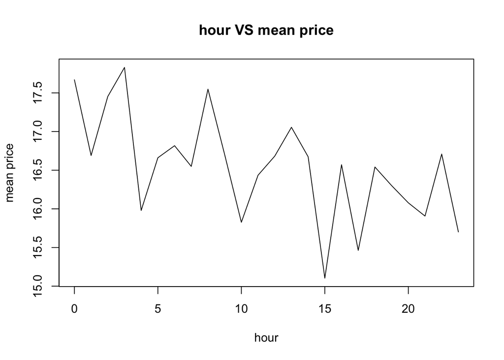

```r
# Group by 'hour' and calculate the mean of 'price'
df_hour_price <- aggregate(df$price, by=list(hour=df$hour), FUN=mean)
colnames(df_hour_price) <- c("hour", "mean_price")
plot(df_hour_price$hour, df_hour_price$mean_price, type='l',
     xlab='hour', ylab='mean price', main='hour VS mean price')
```

**Company vs price**

We want to see if there is a difference in price in case of uber and lyft.

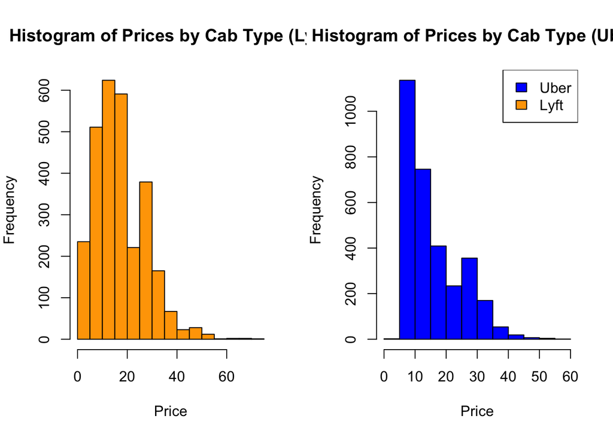

```r
# Create a figure with two subplots
par(mfrow=c(1, 2), mar=c(5, 4, 4, 2))  # 1 row, 2 columns

# Plot histograms by cab_type for Lyft
hist(df$price[df$cab_company == "Lyft"], col="orange", xlab="Price", ylab="Frequency", main="Histogram of Prices by Cab Type (Lyft)")

# Plot histograms by cab_type for Uber
hist(df$price[df$cab_company == "Uber"], col="blue", xlab="Price", ylab="Frequency", main="Histogram of Prices by Cab Type (Uber)")

# Add legend to the figure
legend("topright", legend=c("Uber", "Lyft"), fill=c("blue", "orange"))
```

**Cab types vs Price**

We want to see if cab types affect prices.

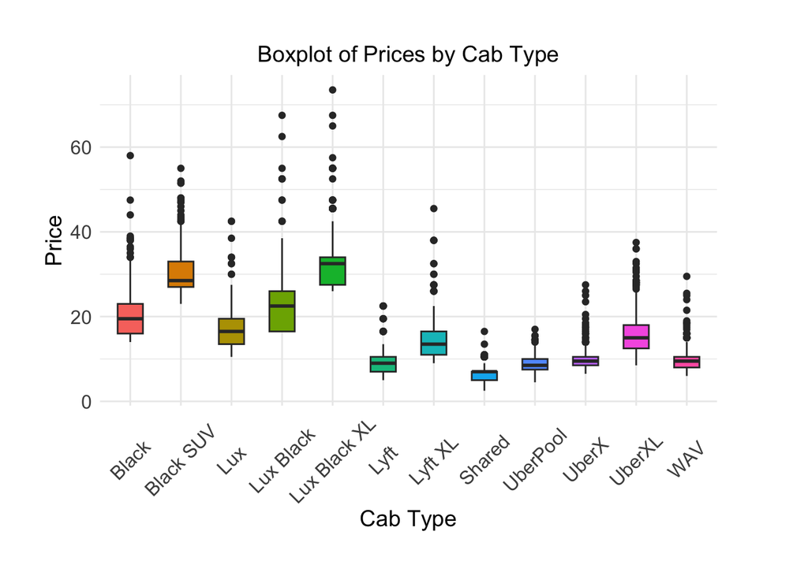

```r
# Create a ggplot object
p <- ggplot(df, aes(x = cab_type, y = price, fill = cab_type)) +
  geom_boxplot(width = 0.5) +
  labs(x = "Cab Type", y = "Price", title = "Boxplot of Prices by Cab Type")

# Adjust the angle and size of x-axis labels
p + theme_minimal() +
  theme(legend.position = "none") +
  theme(plot.title = element_text(hjust = 0.5, size = 14)) +
  theme(axis.text = element_text(size = 12), axis.title = element_text(size = 14)) +
  theme(axis.text.x = element_text(angle = 45, vjust = 0.5, hjust = 0.5)) +  # Adjust the angle
  theme(plot.margin = unit(c(1, 2, 1, 1), "cm"))
```

**Distance vs Price**

Use scatter plot to see the relationship between the distance and price.

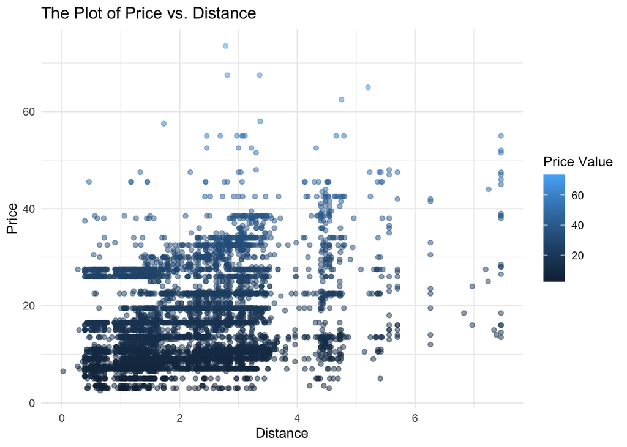

```r
# Scatter plot: Examine the relationship between price and distance
ggplot(df, aes(x = distance, y = price)) +
  geom_point(aes(color = price), alpha = 0.5) +    # Use color to represent the value of price and set point transparency to 0.5
  labs(title = "The Plot of Price vs. Distance",    # Chart title
       x = "Distance",                              # x-axis title
       y = "Price",                                 # y-axis title
       color = "Price Value") +                     # Legend title
  theme_minimal()                                   # Use a minimalistic theme
```

**Surge_multiplier vs Price**

Use boxplot to see the relationship between the surge_multiplier and price.

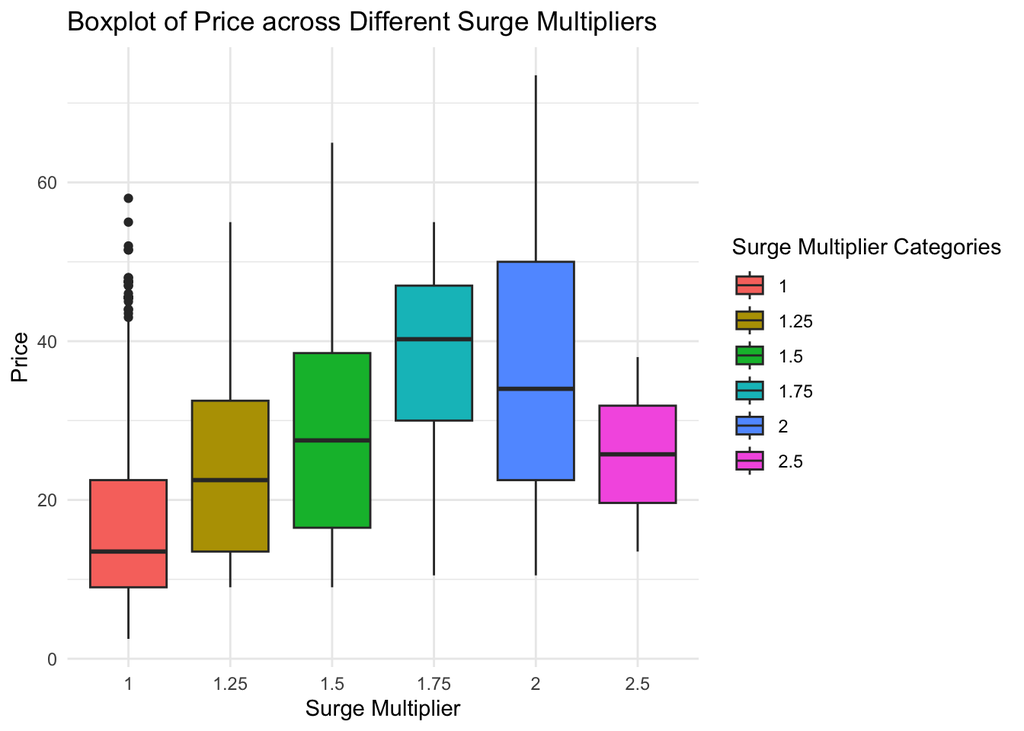

```r
# Box plot: Examine the distribution of price across different surge multipliers
ggplot(df, aes(x = factor(surge_multiplier), y = price)) +  # Convert surge_multiplier to factor for a clearer plot
  geom_boxplot(aes(fill = factor(surge_multiplier))) +        # Fill boxes with colors based on surge_multiplier
  labs(title = "Boxplot of Price across Different Surge Multipliers",
       x = "Surge Multiplier",
       y = "Price",
       fill = "Surge Multiplier Categories") +
  theme_minimal()
```

## Description Statistics

**Show standard deviations**

```r
# measure of variance
sd(df$price)
```

```
## [1] 9.43
```

```r
sd(df$distance)
```

```
## [1] 1.14
```

```r
sd(df$surge_multiplier)
```

```
## [1] 0.103
```

**Test normality**

For hour

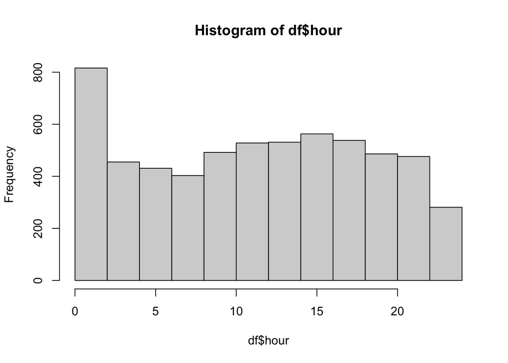

```r
# Create a histogram
hist(df$hour)
```

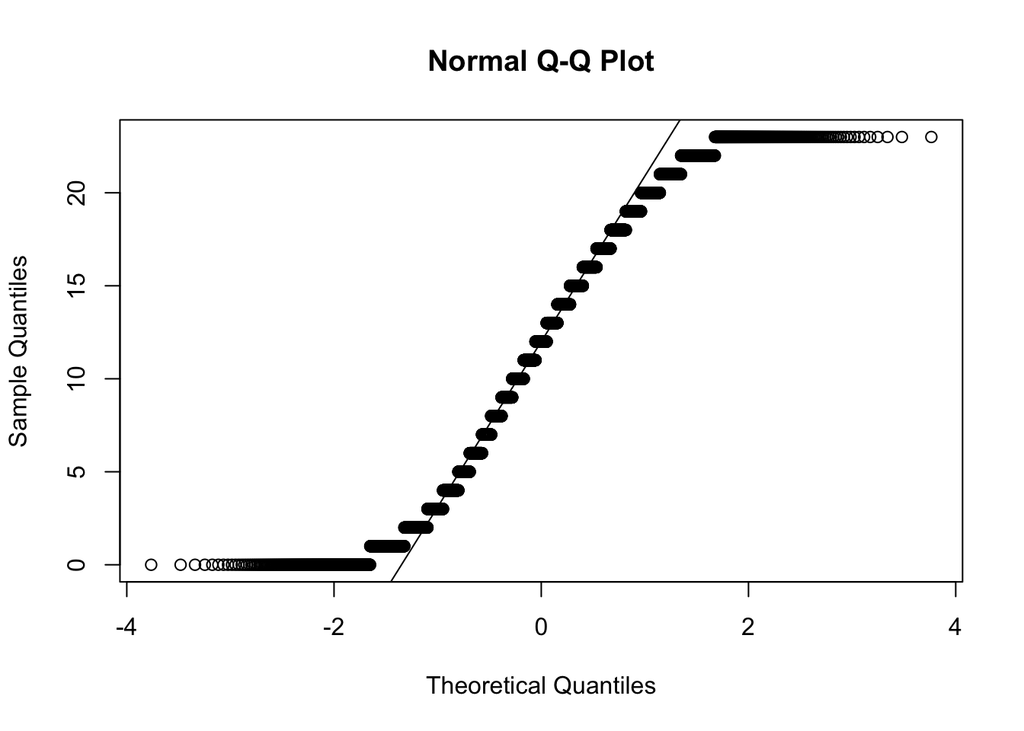

```r
# Create a Q-Q plot
qqnorm(df$hour)
qqline(df$hour)
```

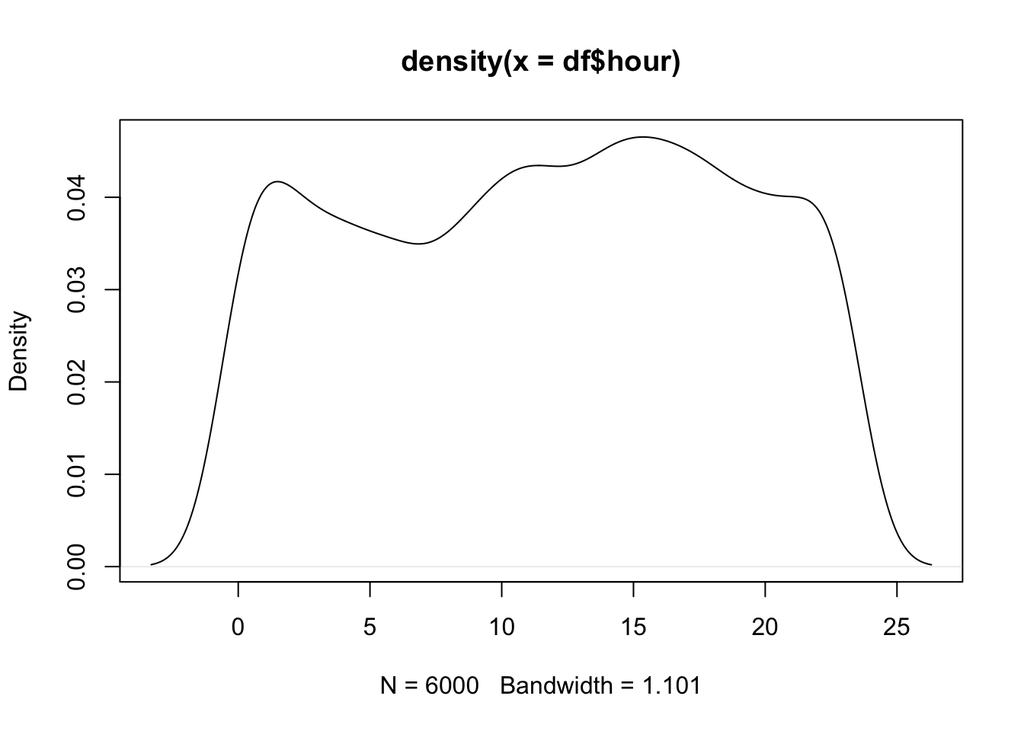

```r
# Create a density plot
plot(density(df$hour))
```

For price

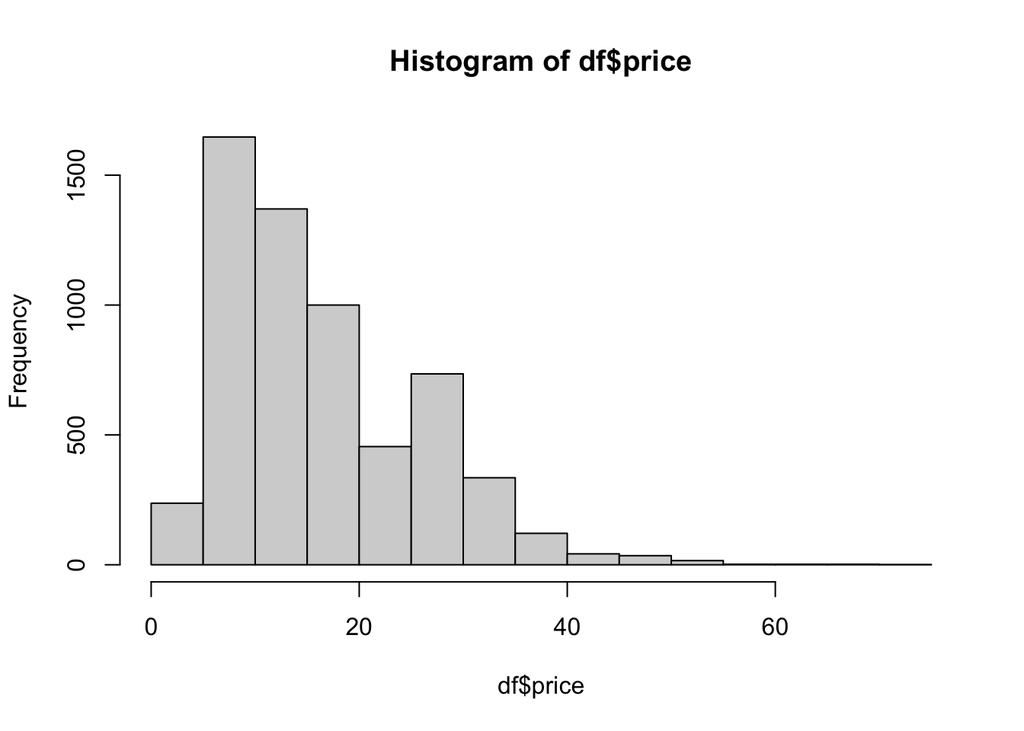

```r
# Create a histogram
hist(df$price)
```

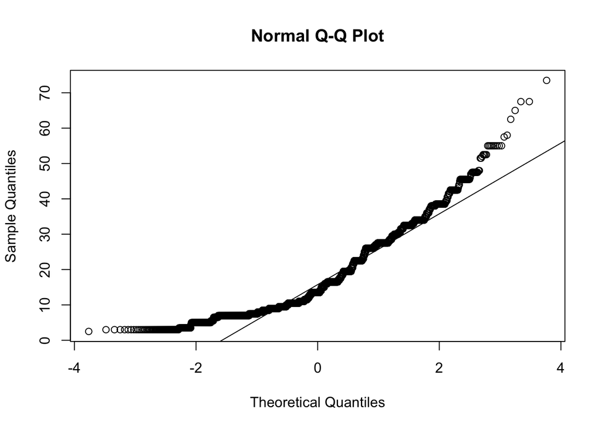

```r
# Create a Q-Q plot
qqnorm(df$price)
qqline(df$price)
```

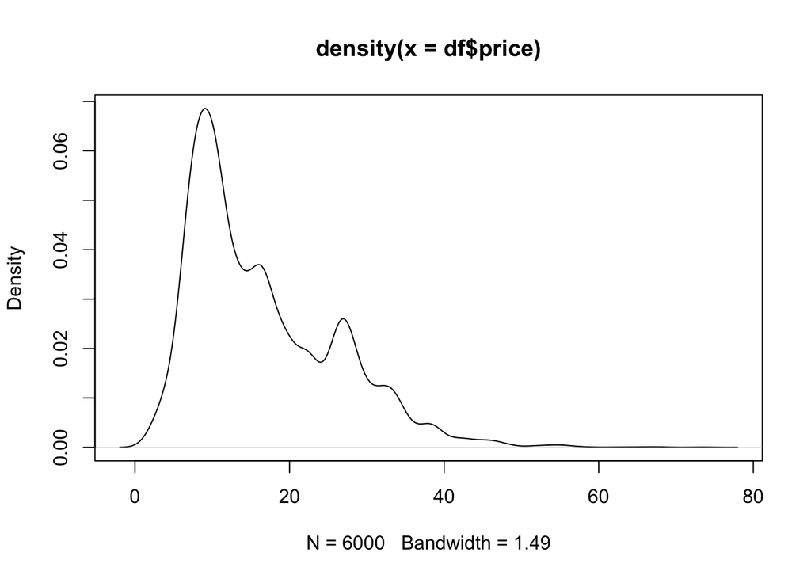

```r
plot(density(df$price))
```

For distance

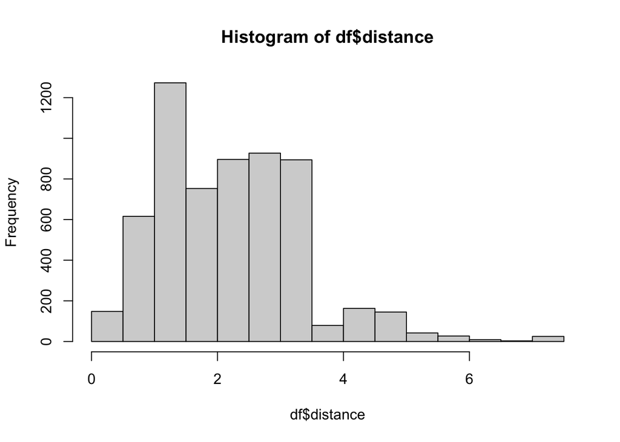

```r
# Create a histogram
hist(df$distance)
```

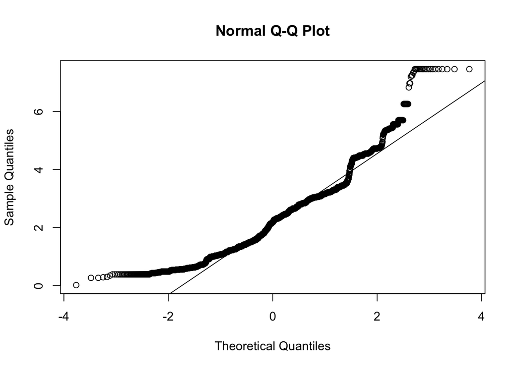

```r
# Create a Q-Q plot
qqnorm(df$distance)
qqline(df$distance)
```

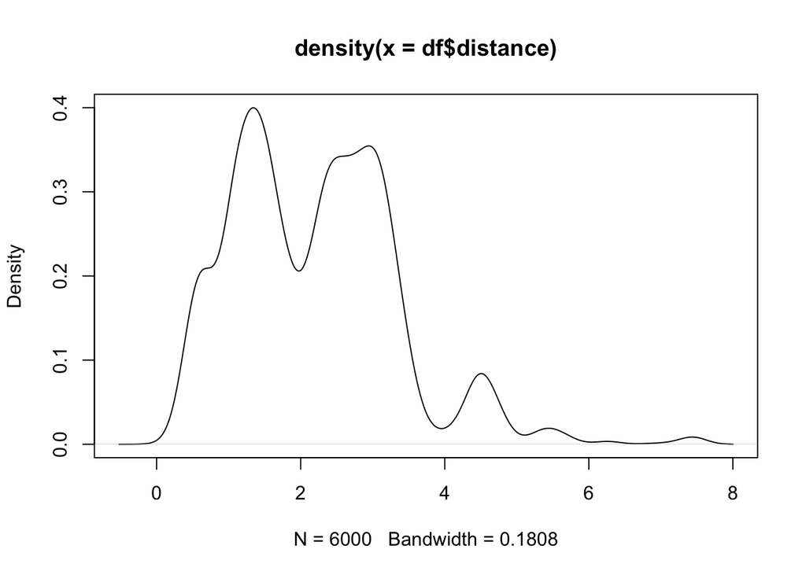

```r
plot(density(df$distance))
```

For surge_multiplier

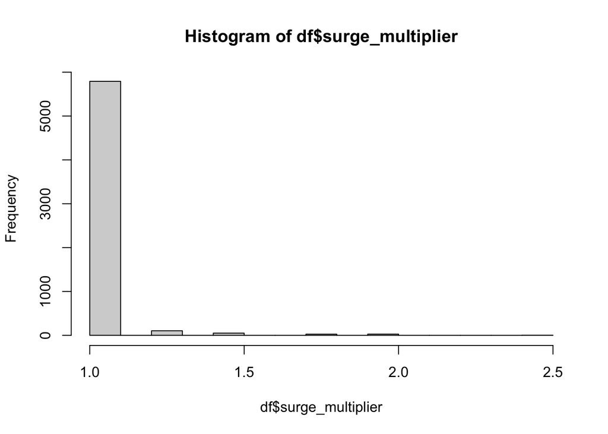

```r
# Create a histogram
hist(df$surge_multiplier)
```

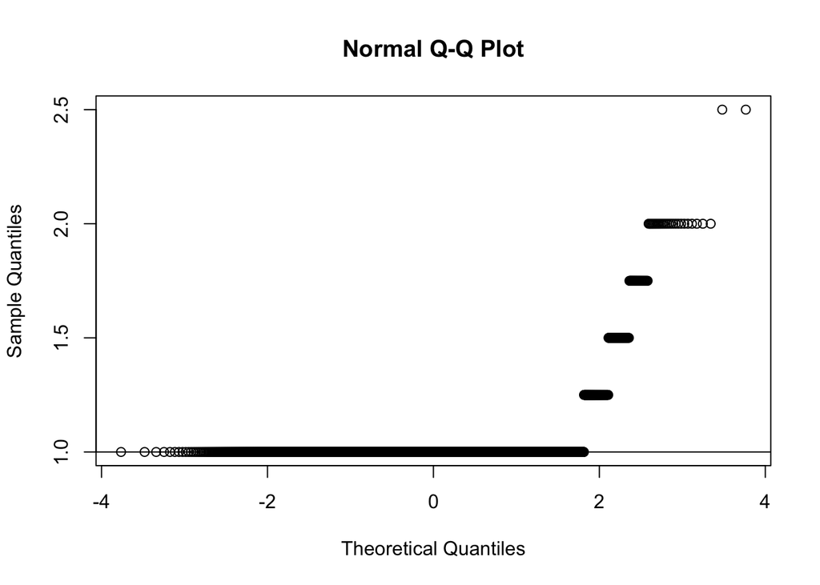

```r
# Create a Q-Q plot
qqnorm(df$surge_multiplier)
qqline(df$surge_multiplier)
```

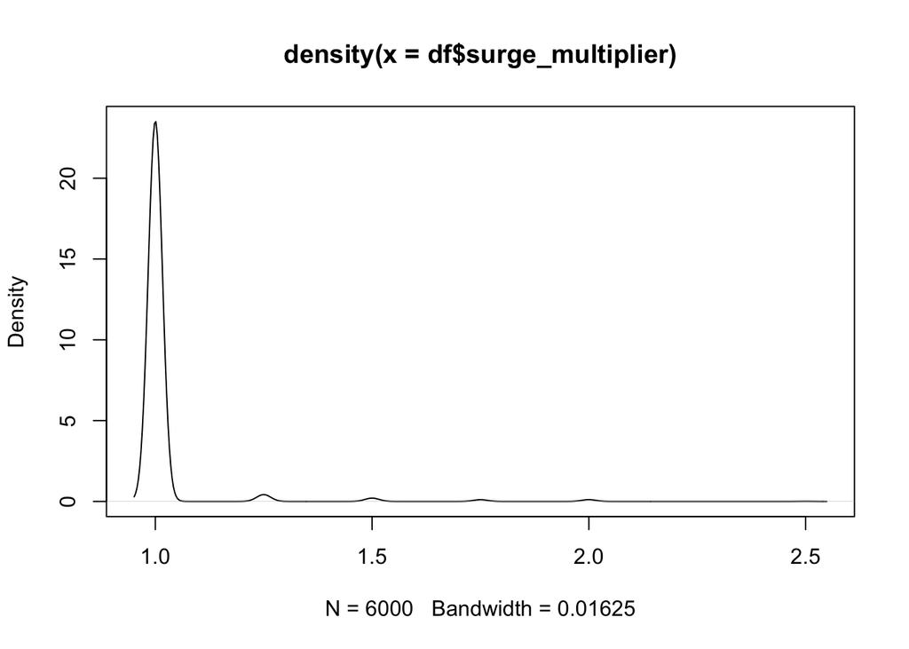

```r
plot(density(df$surge_multiplier))
```

## Correlation Heatmap for Numeric Colmns

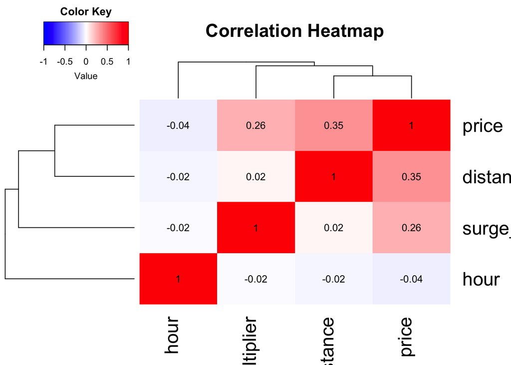

```r
#plot a correlation heat map
df_numeric <- df[,1:4] #only numeric cols
cor_matrix <- cor(df_numeric) #cor matrix

heatmap.2(cor_matrix,
          main = "Correlation Heatmap",  # title
          key = TRUE,  # show color
          density.info = "none",  # prevent duplicate color
          trace = "none",  # prevent trace
          cellnote = round(cor_matrix, 2),  # show cor
          notecol = "black",  # color for cor
          margins = c(5, 5),  # set margins
          col = colorRampPalette(c("blue", "white", "red"))(100)  # set color
)
```

## Chi-Squared Test for Cab_company & Cab_type

```r
# Chi-squared test
chisq_result <- chisq.test(df$cab_company, df$cab_type)

chisq_result
```

```
##
##  Pearson's Chi-squared test
##
## data:  df$cab_company and df$cab_type
## X-squared = 6000, df = 11, p-value <2e-16
```

## Linear Regression Analysis for distance & surge_multiplier & hour

```r
#linear regression analysis
linear_model <- lm(price~distance + surge_multiplier + hour,data = df)
summary(linear_model)
```

```
##
## Call:
## lm(formula = price ~ distance + surge_multiplier + hour, data = df)
##
## Residuals:
##    Min     1Q Median     3Q    Max
## -32.84  -6.71  -1.66   4.96  38.38
##
## Coefficients:
##                  Estimate Std. Error t value Pr(>|t|)
## (Intercept)      -12.4528     1.1286  -11.03   <2e-16 ***
## distance           2.8176     0.0962   29.30   <2e-16 ***
## surge_multiplier  22.8491     1.0701   21.35   <2e-16 ***
## hour              -0.0391     0.0158   -2.48    0.013 *
## ---
## Signif. codes:  0 '***' 0.001 '**' 0.01 '*' 0.05 '.' 0.1 ' ' 1
##
## Residual standard error: 8.52 on 5996 degrees of freedom
## Multiple R-squared:  0.184,  Adjusted R-squared:  0.184
## F-statistic:  452 on 3 and 5996 DF,  p-value: <2e-16
```